# Homework 5: Applied Machine Learning

Josh Gregory

## Canvas assignment instructions

Survived is the class label, that is, whether the person survived (1) or not (0).

The homework for HW 5, use the roadmap for building machine learning systems and the sklearn library, train a kNN algorithm and SVM algorithms. For full credit, perfrom EDA steps and steps to build model in sklearn (step 1 - 6 cleary marked and annotated ) in your .ipynb. Produce learning curves ( accuracy v. number of training examples) for both algorithms and identify whether the learning curves exhibit variance and/or bias. Produce validation curves (accuracy v. hyperparameter) for both algorithms (SVM=C, kNN= # of neighbors) and identify optimal hyperparameters. Which algorithm of the two algorithms performs better?

```python
from IPython.display import Image
%matplotlib inline

#importing the necessary libraries
import pandas as pd
import matplotlib.pyplot as plt
import numpy as np
from sklearn.model_selection import train_test_split, cross_val_score, cross_val_predict
from sklearn.tree import DecisionTreeClassifier
from sklearn.neighbors import KNeighborsClassifier
from sklearn.pipeline import make_pipeline
from sklearn.pipeline import make_pipeline
from sklearn.metrics import classification_report, accuracy_score, confusion_matrix
from sklearn.preprocessing import StandardScaler
from sklearn import tree, preprocessing
import seaborn as sns
sns.set()
```

## Perform EDA according to ICHW 1

### 1. Find the different classes, number of classes, and the number of samples within each class from ICHW1/HW1

```python
data = pd.read_csv('accident.csv')

data
```

|  | PassengerId | Survived | class | Name | Sex | Fare |
| --- | --- | --- | --- | --- | --- | --- |
| 0 | 1 | 0 | 3 | Braund, Mr. Owen Harris | male | 7.2500 |
| 1 | 2 | 1 | 1 | Cumings, Mrs. John Bradley (Florence Briggs Th... | female | 71.2833 |
| 2 | 3 | 1 | 3 | Heikkinen, Miss. Laina | female | 7.9250 |
| 3 | 4 | 1 | 1 | Futrelle, Mrs. Jacques Heath (Lily May Peel) | female | 53.1000 |
| 4 | 5 | 0 | 3 | Allen, Mr. William Henry | male | 8.0500 |
| ... | ... | ... | ... | ... | ... | ... |
| 886 | 887 | 0 | 2 | Montvila, Rev. Juozas | male | 13.0000 |
| 887 | 888 | 1 | 1 | Graham, Miss. Margaret Edith | female | 30.0000 |
| 888 | 889 | 0 | 3 | Johnston, Miss. Catherine Helen "Carrie" | female | 23.4500 |
| 889 | 890 | 1 | 1 | Behr, Mr. Karl Howell | male | 30.0000 |
| 890 | 891 | 0 | 3 | Dooley, Mr. Patrick | male | 7.7500 |

891 rows × 6 columns

```python
classes = pd.unique(data['Survived'])
num_classes = len(classes)
each_class = data['Survived'].value_counts()

print(classes)
print(num_classes)
print(each_class)

print(data.info())
```

```
[0 1]
2
0    549
1    342
Name: Survived, dtype: int64
<class 'pandas.core.frame.DataFrame'>
RangeIndex: 891 entries, 0 to 890
Data columns (total 6 columns):
 #   Column       Non-Null Count  Dtype
---  ------       --------------  -----
 0   PassengerId  891 non-null    int64
 1   Survived     891 non-null    int64
 2   class        891 non-null    int64
 3   Name         891 non-null    object
 4   Sex          891 non-null    object
 5   Fare         891 non-null    float64
dtypes: float64(1), int64(3), object(2)
memory usage: 41.9+ KB
None
```

**What are the names of the features?** PassengerID, class, Name, Sex, and Fare

**What are the types of fetures?** PassengerID is continuous (1 to number of passengers) Sex is binary (Male or Female) Class is trinary (1, 2, 3) Name is a string Fare is continuous

**How many samples do we have?** There are 891 samples.

**How many features do we have?** We have five features total

**What are the classes?** The classes are 0 (died) or survived (1).

**How many classes do we have?** Two

**How many samples of each class? are they balanced?** 0: 549 1: 342

Because some classes have more than others (i.e. more died than survived), these classes are not balanced.

### 2. Check missing values, outliers, and statistics

```python
data.isna().apply(pd.value_counts)
```

|  | PassengerId | Survived | class | Name | Sex | Fare |
| --- | --- | --- | --- | --- | --- | --- |
| False | 891 | 891 | 891 | 891 | 891 | 891 |

### Answers to questions

**Are there any missing values?** No. Since the previous line returned `False`, there are no values that are missing. Therefore, nothing needs to be done to get rid of outliers.

**Are there anomolies in the statistics?** No.

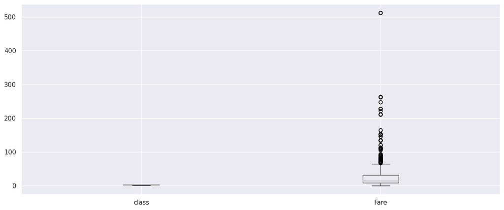

|  | count | mean | std | min | 25% | 50% | 75% | max |
| --- | --- | --- | --- | --- | --- | --- | --- | --- |
| PassengerId | 891.0 | 446.000000 | 257.353842 | 1.0 | 223.5000 | 446.0000 | 668.5 | 891.0000 |
| Survived | 891.0 | 0.383838 | 0.486592 | 0.0 | 0.0000 | 0.0000 | 1.0 | 1.0000 |
| class | 891.0 | 2.308642 | 0.836071 | 1.0 | 2.0000 | 3.0000 | 3.0 | 3.0000 |
| Fare | 891.0 | 32.204208 | 49.693429 | 0.0 | 7.9104 | 14.4542 | 31.0 | 512.3292 |

```python
data.boxplot(column=['class', 'Fare'], figsize = (15,6))
plt.show()
data.describe().T
```

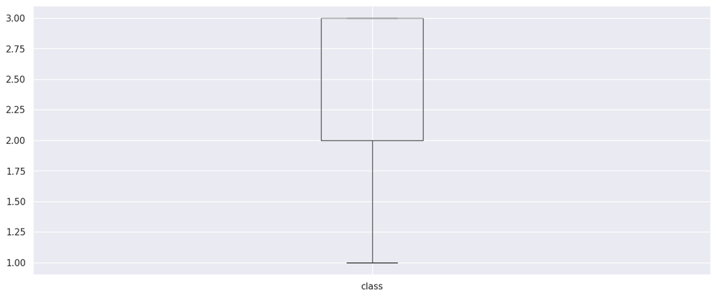

```python
data.boxplot(column=['class'], figsize = (15,6))
plt.show()
```

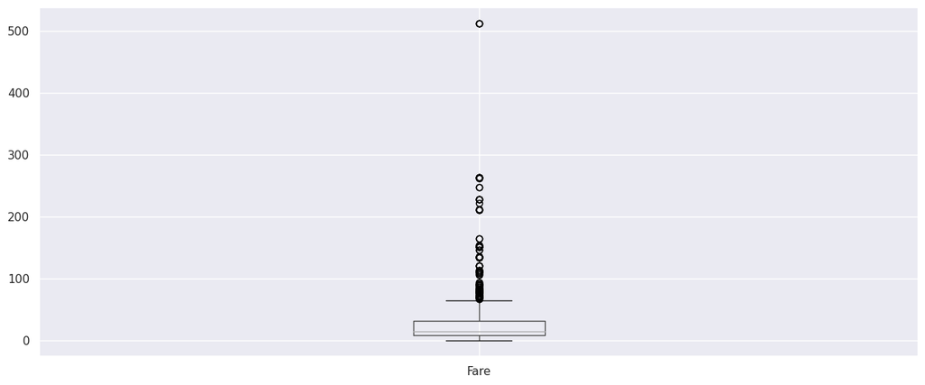

```python
data.boxplot(column=['Fare'], figsize = (15,6))
plt.show()
```

Changes to make to the dataset:

1. Change the 'Sex' column to the following: 'M':0, 'F': 1
2. Don't do anything to the`Fare` class, and instead have the scalers in sklearn handle scaling of the data.

```python
# Implementing step 1
sex_dict = {"male": 0, "female": 1}
data['Sex'] = data['Sex'].replace(sex_dict)

# Implementing step 2
# percentile = 31.0
# data.loc[data['Fare'] >= percentile, 'Fare'] = percentile
```

### Check distributions and correlations

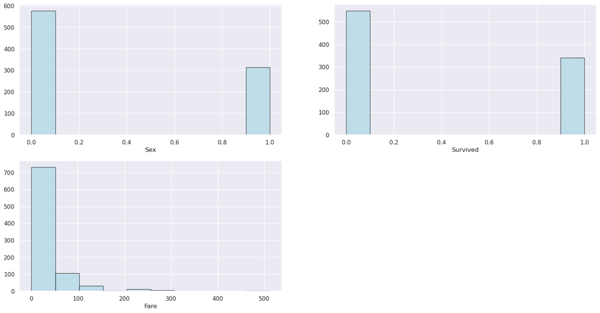

```python
plt.figure(figsize= (20,10))
plt.subplot(2, 2, 1)
plt.hist(data['Sex'], color='lightblue', edgecolor = 'black', alpha = 0.7)
plt.xlabel('Sex')

plt.subplot(2, 2, 2)
plt.hist(data['Survived'], color='lightblue', edgecolor = 'black', alpha = 0.7)
plt.xlabel('Survived')

plt.subplot(2,2,3)
plt.hist(data['Fare'], color='lightblue', edgecolor = 'black', alpha = 0.7)
plt.xlabel('Fare')

# plt.subplot(2,2,4)
# plt.hist(data['PassengerID'], color='lightblue', edgecolor = 'black', alpha = 0.7)
# plt.xlabel('PassengerID')
plt.show()
```

**What kind of distributions do the features have?**

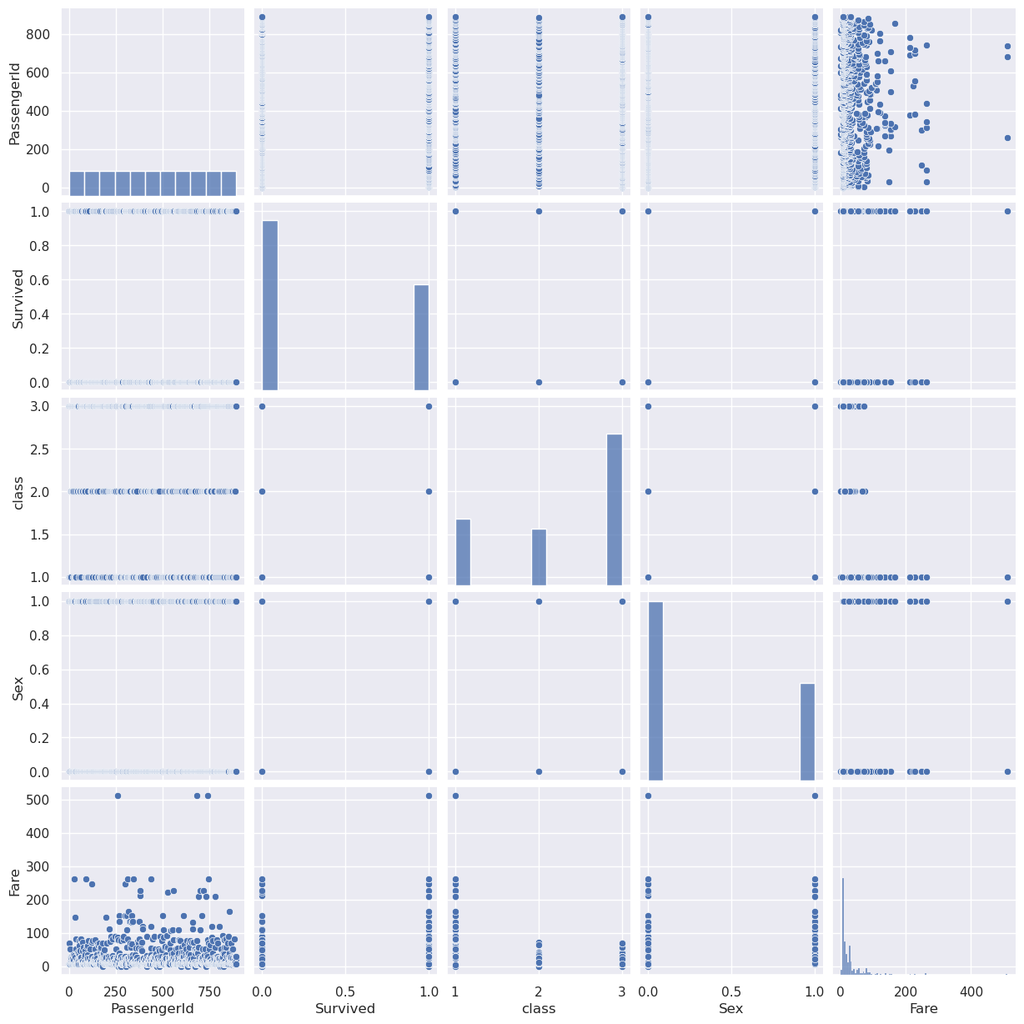

```python
sns.pairplot(data) # pairplot
plt.show()
```

**What kind of correlation does the data exhibit?**

It doesn't appear that there is any strong correlation within the data. The strongest correlation is between `Class` and `Fare`.

```python
data.corr()
```

|  | PassengerId | Survived | class | Sex | Fare |
| --- | --- | --- | --- | --- | --- |
| PassengerId | 1.000000 | -0.005007 | -0.035144 | -0.042939 | 0.012658 |
| Survived | -0.005007 | 1.000000 | -0.338481 | 0.543351 | 0.257307 |
| class | -0.035144 | -0.338481 | 1.000000 | -0.131900 | -0.549500 |
| Sex | -0.042939 | 0.543351 | -0.131900 | 1.000000 | 0.182333 |
| Fare | 0.012658 | 0.257307 | -0.549500 | 0.182333 | 1.000000 |

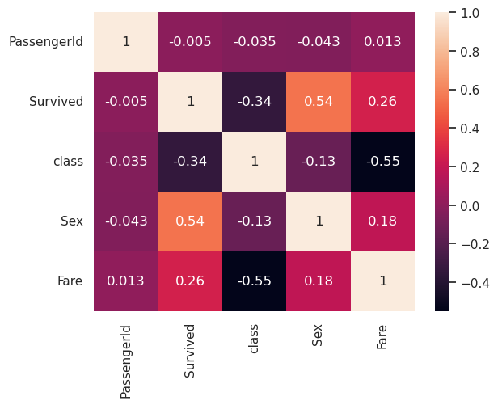

```python
sns.heatmap(data.corr(), annot = True)
plt.show()
```

## kNN Model

Only pulling the features `class`, `sex`, and `fare` since the `Name` and `PassengerId` features have no correlation with whether someone survives or not, so it would just be eating computation.

```python
x = data.iloc[:, [2,4,5]]
y = data.iloc[:, 1]
```

```python
# Split the data into training, validation, and test datasets
# x_train, x_test, y_train, y_test = train_test_split(x, y, test_size=0.2, random_state=42)

# Split the data into training, validation, and test datasets
X_train_val, X_test, y_train_val, y_test = train_test_split(x, y, test_size=0.2, random_state=42)
X_train, X_val, y_train, y_val = train_test_split(X_train_val, y_train_val, test_size=0.25, random_state=42)
```

```python
k_range = range(1,11)
#print(k_range)


for k in k_range:
    #select an algorithm
    model = KNeighborsClassifier(n_neighbors=k)
    # model = DecisionTreeClassifier(criterion = 'gini', max_depth=k)
    model.fit(X_train, y_train)
    test_score = model.score(X_test,y_test)
    train_score = model.score(X_train,y_train)
    print("k: ", k)
    print(f"Train Accuracy: {train_score}")
    print(f"Test Accuracy: {test_score}")
```

```
k:  1
Train Accuracy: 0.9026217228464419
Test Accuracy: 0.7821229050279329
k:  2
Train Accuracy: 0.8558052434456929
Test Accuracy: 0.7597765363128491
k:  3
Train Accuracy: 0.8576779026217228
Test Accuracy: 0.7597765363128491
k:  4
Train Accuracy: 0.8314606741573034
Test Accuracy: 0.7262569832402235
k:  5
Train Accuracy: 0.8202247191011236
Test Accuracy: 0.7206703910614525
k:  6
Train Accuracy: 0.8164794007490637
Test Accuracy: 0.7150837988826816
k:  7
Train Accuracy: 0.8183520599250936
Test Accuracy: 0.7318435754189944
k:  8
Train Accuracy: 0.8033707865168539
Test Accuracy: 0.7206703910614525
k:  9
Train Accuracy: 0.7865168539325843
Test Accuracy: 0.7318435754189944
k:  10
Train Accuracy: 0.7883895131086143
Test Accuracy: 0.7206703910614525
```

```python
k_range = range(1,21)
#print(k_range)

for k in k_range:
    model = DecisionTreeClassifier(criterion = 'gini', max_depth=k)
    model.fit(X_train, y_train)
    train_accuracy = model.score(X_train,y_train)
    y_pred = model.predict(X_val)
    val_accuracy = accuracy_score(y_val, y_pred)
    print("k: ", k)
    print(f"Training Accuracy: {train_accuracy}")
    print(f"Validation Accuracy: {val_accuracy}")
    y_pred_test = model.predict(X_test)
    accuracy_test = accuracy_score(y_test, y_pred_test)
    print(f"Test Accuracy: {accuracy_test}")
    print()
    print()
```

```
k:  1
Training Accuracy: 0.7790262172284644
Validation Accuracy: 0.8146067415730337
Test Accuracy: 0.7821229050279329


k:  2
Training Accuracy: 0.7808988764044944
Validation Accuracy: 0.8258426966292135
Test Accuracy: 0.7653631284916201


k:  3
Training Accuracy: 0.8108614232209738
Validation Accuracy: 0.8370786516853933
Test Accuracy: 0.8044692737430168


k:  4
Training Accuracy: 0.8183520599250936
Validation Accuracy: 0.8033707865168539
Test Accuracy: 0.7932960893854749


k:  5
Training Accuracy: 0.8426966292134831
Validation Accuracy: 0.8146067415730337
Test Accuracy: 0.7821229050279329


k:  6
Training Accuracy: 0.8558052434456929
Validation Accuracy: 0.8089887640449438
Test Accuracy: 0.7932960893854749


k:  7
Training Accuracy: 0.8745318352059925
Validation Accuracy: 0.8258426966292135
Test Accuracy: 0.8156424581005587
```

[output cut: 63 more lines]

```
Training Accuracy: 0.9176029962546817
Validation Accuracy: 0.8146067415730337
Test Accuracy: 0.8324022346368715


k:  19
Training Accuracy: 0.9176029962546817
Validation Accuracy: 0.8146067415730337
Test Accuracy: 0.8324022346368715


k:  20
Training Accuracy: 0.9176029962546817
Validation Accuracy: 0.8146067415730337
Test Accuracy: 0.8379888268156425
```

```python
from sklearn.model_selection import KFold

kf = KFold(n_splits=10, shuffle = True)
print(kf)

scores = []

for i, (train_index, val_index) in enumerate(kf.split(x)):
    print(f"Fold {i}:")
    print(f"  Train: index={train_index}")
    print(f"  Test:  index={val_index}")

    # Splitting the training set from the validation set for this specific fold
    X_train, X_val = x.iloc[train_index, :], x.iloc[val_index, :]
    y_train, y_val = y.iloc[train_index], y.iloc[val_index]

    #print(X_train)
    #print(y_train)
    #print(X_val)
    #print(y_val)

    model.fit(X_train, y_train)
    score = model.score(X_val, y_val)
    print(f"accuracy score: ", score)

    y_pred = model.predict(X_val)

    scores.append(score)
```

[output not shown]

[output cut: 506 more lines]

```
range(0, 10)
[0.8555555555555555, 0.8426966292134831, 0.8089887640449438, 0.8202247191011236, 0.7640449438202247, 0.8426966292134831, 0.797752808988764, 0.8202247191011236, 0.8314606741573034, 0.8202247191011236]
```

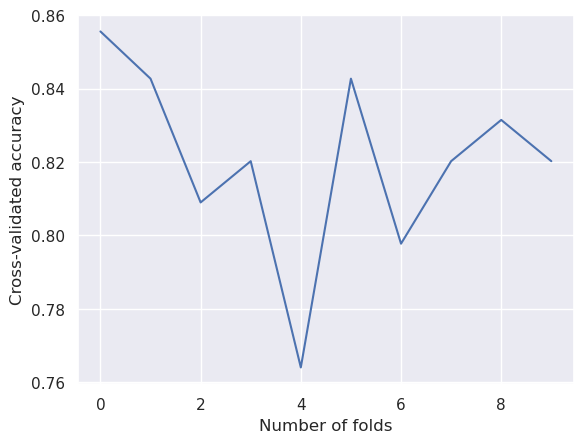

```python
# plot how accuracy changes as we vary hyperparameter
import matplotlib.pyplot as plt
%matplotlib inline

# plot the value of hyperparameter (x-axis) versus the cross-validated accuracy (y-axis)
# plt.plot(x_axis, y_axis)

k_range = range(10)
print(k_range)
print(scores)
plt.plot(k_range, scores)
plt.xlabel('Number of folds')
plt.ylabel('Cross-validated accuracy')
plt.show()
```

### kNN Learning Curves

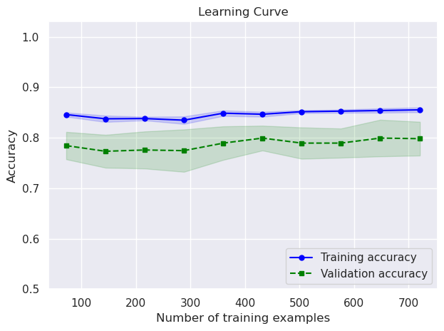

```python
import matplotlib.pyplot as plt
from sklearn.model_selection import learning_curve
from sklearn.preprocessing import StandardScaler
from sklearn.pipeline import make_pipeline
from sklearn.neighbors import KNeighborsClassifier

pipe_knn = make_pipeline(StandardScaler(), KNeighborsClassifier(n_neighbors=5))

train_sizes, train_scores, test_scores =\
                learning_curve(estimator=pipe_knn,
                               X=X_train,
                               y=y_train,
                               train_sizes=np.linspace(0.1, 1.0, 10),
                               cv=10,
                               n_jobs=1)

#print(train_sizes)

train_mean = np.mean(train_scores, axis=1)
train_std = np.std(train_scores, axis=1)
test_mean = np.mean(test_scores, axis=1)
test_std = np.std(test_scores, axis=1)

plt.plot(train_sizes, train_mean,
         color='blue', marker='o',
         markersize=5, label='Training accuracy')

plt.fill_between(train_sizes,
                 train_mean + train_std,
                 train_mean - train_std,
                 alpha=0.15, color='blue')

plt.plot(train_sizes, test_mean,
         color='green', linestyle='--',
         marker='s', markersize=5,
         label='Validation accuracy')

plt.fill_between(train_sizes,
                 test_mean + test_std,
                 test_mean - test_std,
                 alpha=0.15, color='green')

plt.grid(True)
plt.xlabel('Number of training examples')
plt.ylabel('Accuracy')
plt.legend(loc='lower right')
plt.title("Learning Curve")
plt.ylim([0.5, 1.03])
plt.tight_layout()
# plt.savefig('images/06_05.png', dpi=300)
plt.show()
```

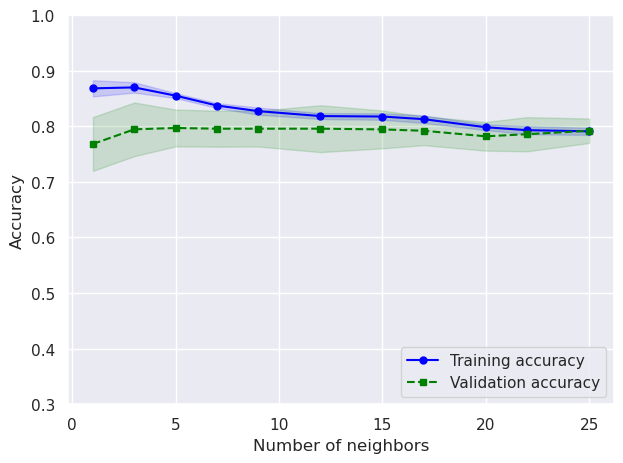

```python
from sklearn.model_selection import validation_curve

param_range = [1, 3, 5, 7, 9, 12, 15, 17, 20, 22, 25]
train_scores, test_scores = validation_curve(
                estimator=pipe_knn,
                X=X_train,
                y=y_train,
                param_name='kneighborsclassifier__n_neighbors',
                param_range=param_range,
                cv=10)

train_mean = np.mean(train_scores, axis=1)
train_std = np.std(train_scores, axis=1)
test_mean = np.mean(test_scores, axis=1)
test_std = np.std(test_scores, axis=1)

plt.plot(param_range, train_mean,
         color='blue', marker='o',
         markersize=5, label='Training accuracy')

plt.fill_between(param_range, train_mean + train_std,
                 train_mean - train_std, alpha=0.15,
                 color='blue')

plt.plot(param_range, test_mean,
         color='green', linestyle='--',
         marker='s', markersize=5,
         label='Validation accuracy')

plt.fill_between(param_range,
                 test_mean + test_std,
                 test_mean - test_std,
                 alpha=0.15, color='green')

plt.grid(True)
# plt.xscale('log')
plt.legend(loc='lower right')
plt.xlabel('Number of neighbors')
plt.ylabel('Accuracy')
plt.ylim([0.3, 1.0])
plt.tight_layout()
# plt.savefig('images/06_06.png', dpi=300)
plt.show()
```

### SVM Learning Curves

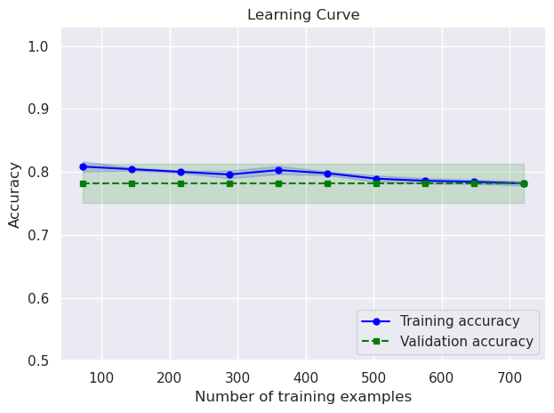

```python
import matplotlib.pyplot as plt
from sklearn.model_selection import learning_curve
from sklearn.preprocessing import StandardScaler
from sklearn.pipeline import make_pipeline
from sklearn.svm import SVC

pipe_svc = make_pipeline(StandardScaler(), SVC(kernel="linear", C=1.0))

train_sizes, train_scores, test_scores =\
                learning_curve(estimator=pipe_svc,
                               X=X_train,
                               y=y_train,
                               train_sizes=np.linspace(0.1, 1.0, 10),
                               cv=10,
                               n_jobs=1)

#print(train_sizes)

train_mean = np.mean(train_scores, axis=1)
train_std = np.std(train_scores, axis=1)
test_mean = np.mean(test_scores, axis=1)
test_std = np.std(test_scores, axis=1)

plt.plot(train_sizes, train_mean,
         color='blue', marker='o',
         markersize=5, label='Training accuracy')

plt.fill_between(train_sizes,
                 train_mean + train_std,
                 train_mean - train_std,
                 alpha=0.15, color='blue')

plt.plot(train_sizes, test_mean,
         color='green', linestyle='--',
         marker='s', markersize=5,
         label='Validation accuracy')

plt.fill_between(train_sizes,
                 test_mean + test_std,
                 test_mean - test_std,
                 alpha=0.15, color='green')

plt.grid(True)
plt.xlabel('Number of training examples')
plt.ylabel('Accuracy')
plt.legend(loc='lower right')
plt.title("Learning Curve")
plt.ylim([0.5, 1.03])
plt.tight_layout()
# plt.savefig('images/06_05.png', dpi=300)
plt.show()
```

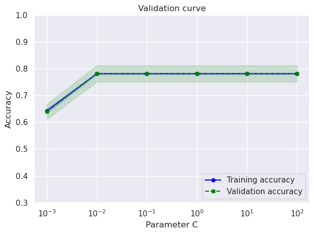

```python
from sklearn.model_selection import validation_curve

param_range = [0.001, 0.01, 0.1, 1.0, 10.0, 100.0]
train_scores, test_scores = validation_curve(
                estimator=pipe_svc,
                X=X_train,
                y=y_train,
                param_name='svc__C',
                param_range=param_range,
                cv=10)

train_mean = np.mean(train_scores, axis=1)
train_std = np.std(train_scores, axis=1)
test_mean = np.mean(test_scores, axis=1)
test_std = np.std(test_scores, axis=1)

plt.plot(param_range, train_mean,
         color='blue', marker='o',
         markersize=5, label='Training accuracy')

plt.fill_between(param_range, train_mean + train_std,
                 train_mean - train_std, alpha=0.15,
                 color='blue')

plt.plot(param_range, test_mean,
         color='green', linestyle='--',
         marker='s', markersize=5,
         label='Validation accuracy')

plt.fill_between(param_range,
                 test_mean + test_std,
                 test_mean - test_std,
                 alpha=0.15, color='green')

plt.grid(True)
plt.xscale('log')
plt.title('Validation curve')
plt.legend(loc='lower right')
plt.xlabel('Parameter C')
plt.ylabel('Accuracy')
plt.ylim([0.3, 1.0])
plt.tight_layout()
# plt.savefig('images/06_06.png', dpi=300)
plt.show()
```

## Training both algorithms with optimal hyperparameters

I'm going to use regular hold-out CV and train both a kNN and SVM algorithm with the following hyperparameters:

```python
X_train, X_test, y_train, y_test = train_test_split(x, y, test_size=0.2, random_state=42)
```

```python
from sklearn import metrics

model = KNeighborsClassifier(n_neighbors=17)

model.fit(X_train, y_train)

y_pred = model.predict(X_test)
print(f'kNN accuracy: {metrics.accuracy_score(y_test, y_pred)}')
```

```
kNN accuracy: 0.7486033519553073
```

```python
from sklearn import metrics
from sklearn.svm import SVC

model = SVC(kernel='linear',C=1.0)

model.fit(X_train, y_train)

y_pred = model.predict(X_test)
print(f'SVM accuracy: {metrics.accuracy_score(y_test, y_pred)}')
```

```
SVM accuracy: 0.7821229050279329
```